# PROJET FINAL - DATA SCIENCE

Lucas Alves et Claire Oddon

4/4/2022

## Introduction

We have chosen to analyse data from multiple databases that contain information about the happiness at work. Originally, this study was dedicated to understanding the relationship between the happiness at work and the turnover rates. The data was collected from 37 companies based on Barcelona. To collect this data, the researches created an app that allowed employees to evaluate their companies by giving a vote ranging from 1 to 4. After voting, the employees were invited to see the commentaries and the votes from their peers. Thus, they were allowed to react by liking or disliking the commentary.

The data have been analysed by diverse data scientists and they normally concludes that it does not seem to have a relationship between the variable. However, are there more information that could we extract from this interesting database?

In this study, we will first analyse and understand the 4 databases provided (churn, commentinteractions, commentclean and votes). Then, we will explore visually some characteristics of the employees based on the data provided like: the mean happiness based on the mean vote and the relationship between feedback and turnover. In the end, we will answer our main question: are the radical votes (the highest and the lowest) the ones that generate more interaction?

## Summary of each database

Now that each database is an object, we can begin by summarizing each database to understand the characteristics of each variable:

```r
summary(commentclean)
```

```
##     employee      companyAlias        commentId             txt
##  Min.   :-217.0   Length:82756       Length:82756       Length:82756
##  1st Qu.:  29.0   Class :character   Class :character   Class :character
##  Median : 102.0   Mode  :character   Mode  :character   Mode  :character
##  Mean   : 135.1
##  3rd Qu.: 197.0
##  Max.   : 999.0
##
##      likes           dislikes      commentDate
##  Min.   : 0.000   Min.   : 0.000   Length:82756
##  1st Qu.: 2.000   1st Qu.: 0.000   Class :character
##  Median : 4.000   Median : 0.000   Mode  :character
##  Mean   : 6.873   Mean   : 1.271
##  3rd Qu.: 9.000   3rd Qu.: 1.000
##  Max.   :86.000   Max.   :53.000
##  NA's   :1        NA's   :1
```

```r
summary(votes)
```

```
##     employee     companyAlias         voteDate              vote
##  Min.   :  1.0   Length:221232      Length:221232      Min.   :1.000
##  1st Qu.: 50.0   Class :character   Class :character   1st Qu.:2.000
##  Median :127.0   Mode  :character   Mode  :character   Median :3.000
##  Mean   :172.1                                         Mean   :2.862
##  3rd Qu.:222.0                                         3rd Qu.:4.000
##  Max.   :999.0                                         Max.   :4.000
```

```r
summary(commentinteractions)
```

```
##     employee      companyAlias         liked          disliked
##  Min.   :-218.0   Length:336959      Mode :logical   Mode :logical
##  1st Qu.:  38.0   Class :character   FALSE:52561     FALSE:284398
##  Median : 122.0   Mode  :character   TRUE :284398    TRUE :52561
##  Mean   : 162.9
##  3rd Qu.: 212.0
##  Max.   : 999.0
##   commentId
##  Length:336959
##  Class :character
##  Mode  :character
##
##
##
```

```r
summary(churn)
```

```
##     employee      companyAlias          numVotes     lastParticipationDate
##  Min.   :-218.0   Length:4847        Min.   :  0.0   Length:4847
##  1st Qu.:  33.0   Class :character   1st Qu.:  3.0   Class :character
##  Median : 113.0   Mode  :character   Median : 16.0   Mode  :character
##  Mean   : 167.4                      Mean   : 45.9
##  3rd Qu.: 231.0                      3rd Qu.: 59.0
##  Max.   : 999.0                      Max.   :740.0
##  stillExists
##  Mode :logical
##  FALSE:1174
##  TRUE :3673
##
##
##
```

## Understanding the negative values in employee column in Churn

The first thing that caught our attention was the presence of employees represented by negative IDs. Why have they negative IDs? To answer that question, we have began by looking at the quantity of employees with Negative IDs.

```r
churn %>%
  filter(employee < 0) %>%
  count(employee)
```

```
## # A tibble: 214 × 2
##    employee     n
##       <dbl> <int>
##  1     -218     1
##  2     -217     1
##  3     -216     1
##  4     -215     1
##  5     -214     1
##  6     -213     1
##  7     -212     1
##  8     -211     1
##  9     -210     1
## 10     -209     1
## # … with 204 more rows
```

## Conclusion1 : There are 214 employees with negative values

To continue our analysis, we decided to test the hypothesis of a relationship between be churned (quit the company) and having negative value ID. To proceed with this test, we have counted the quantity of employees with negative IDs that are still on the company and those of employees with negative IDs that are still on the company.

```r
churn %>%
  filter(employee < 0) %>%
  count(stillExists)
```

```
## # A tibble: 1 × 2
##   stillExists     n
##   <lgl>       <int>
## 1 FALSE         429
```

```r
churn %>%
  filter(employee > 0) %>%
  count(stillExists)
```

```
## # A tibble: 2 × 2
##   stillExists     n
##   <lgl>       <int>
## 1 FALSE         745
## 2 TRUE         3673
```

## Conclusion2: Inconclusive

Our first hypothesis was proved false. According to the first table, every single employee who has a negative ID is not in the company anymore. However, when we look at the second table, we verify that there are also employees with positive ID that are not anymore in the company

Therefore, we have decided to filter the negative values of the DataBase Churn and to create some new objects

```r
churn_positive <- churn %>%
  filter(employee > 0)

churn_positive_join <- churn %>%
  filter(employee > 0) %>%
  na.omit() %>%
  group_by(employee) %>%
  summarise(sum(numVotes))

churn_positive_main <- churn %>%
  filter(employee >0) %>%
  left_join(churn_positive_join)
```

## Employee per company:

After dealing with the most significant problem of the database, we have decided to explore the data and to proceed to the data wrangling when it is necessary. So, we have decided to verify how many companies we have on the databases and how many employees each company has.

```
## # A tibble: 37 × 2
##    companyAlias                 n
##    <chr>                    <int>
##  1 5370af43e4b0cff95558c12a   224
##  2 53a2dd43e4b01cc02f1e9011   144
##  3 5474b9cde4b0bf7614b2c66f    10
##  4 54d43612e4b0f6a40755d93e    21
##  5 54e52607e4b01191dc064966   585
##  6 552e2d00e4b066b42fd122ed    29
##  7 5641f96713664c000332c8cd   224
##  8 56558cfd07a5de00030908fb    12
##  9 567011c035dce00003a07fa4   165
## 10 56ab28dc1f385d0003454757    34
## # … with 27 more rows
```

## There are 37 companies. However, to each company it was designed a huge ID.

So to make easier the visualization of the graph containing the number of employees per company, we will add a new column to the database with a integer ID ranging from 1 to 37.

```r
employees_company <- churn_positive %>%
  group_by(companyAlias) %>%
  count() %>%
  arrange(desc(n))
company_ID <- list(A = seq(1,37, by=1), B = employees_company$companyAlias)
company_id_df <- as.data.frame(company_ID, col.names = c("Company_ID","companyAlias" ))
employees_company_df <- employees_company %>%
  left_join(company_id_df)
```

## Graph Employees per Company

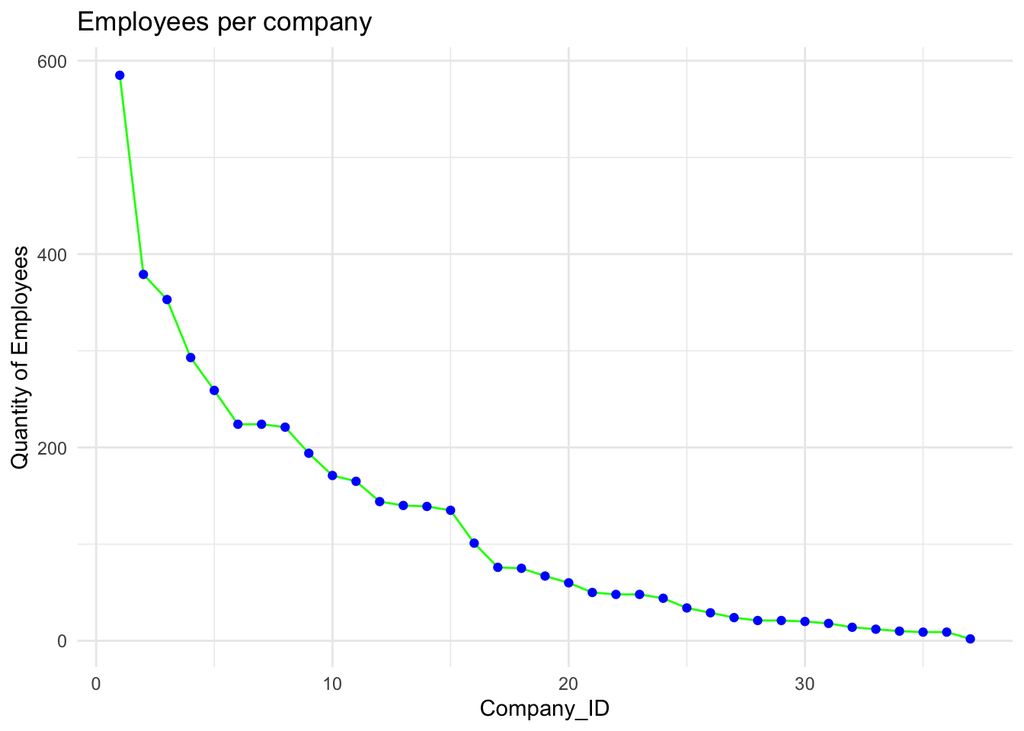

## Conclusion3:

This graph provides us with a simple visualization of the distribution of employees by company. We notice that the companies studied were in general small or medium companies.

## Is the majority of employees happy at their works based on their votes?

To answer this question, we have decided to work with a boxplot visualization. This type of plot allows us to notice easily the out liners and also where lies the majority of the distribution. To use this representation, we proceeded to a Data Wrangling of the votes database to calculate the mean vote and thus the mean happiness.

```r
votes_mean <- votes %>%
  group_by(employee) %>%
  summarise(mean(vote))
names(votes_mean)[2] <- 'mean_vote'
```

## Graph: Mean Happiness

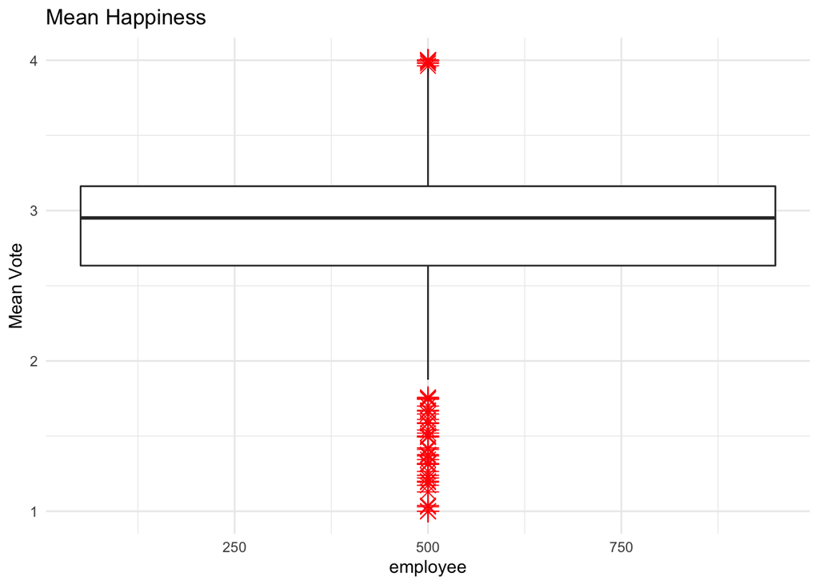

## Conclusion 4: Analyzing this graph, we can notice that the majority of the distribution is located between 2.5 and 3.5. In that case, we can conclude that in average the employees who participated on these research were happy inside their companies. However, it is interesting to see that the majority of the outliers lies between 1 and 2.

## The most active employees are those who stay or quit the company?

Considering that the majority of employees seems happy at their companies. Is the turnover high in the companies we study? To understand that, we have conceived a graph.

## Graphiques Turnover et Feedback et tournouver

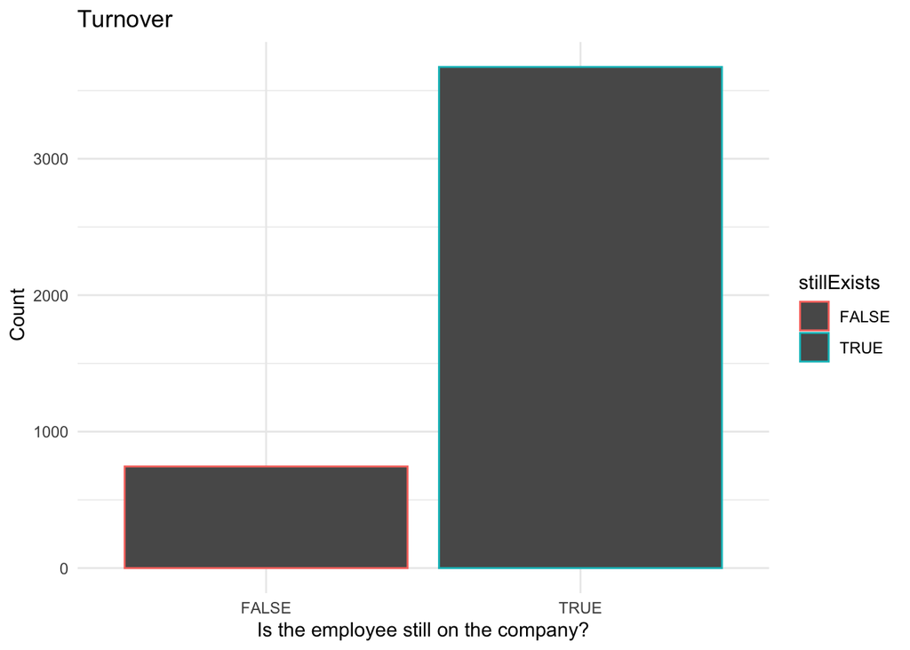

##Conclusion 5: The graph shows us that clearly the majority of the employees are still on their respective companies. Considering that participating on the research was not mandatory and that many employees have decided to do not vote, we can ask ourselves if there is a relationship between staying on the company and participating on the research. In other words, are the employees who gave feedback (voted) on this research more inclination to quit or to stay on the company (even considering that they can note negatively) ?

To answer this question, we generated a graph with three variables: Votes per Employee, Employee Id and Still Exists (left the company or not).

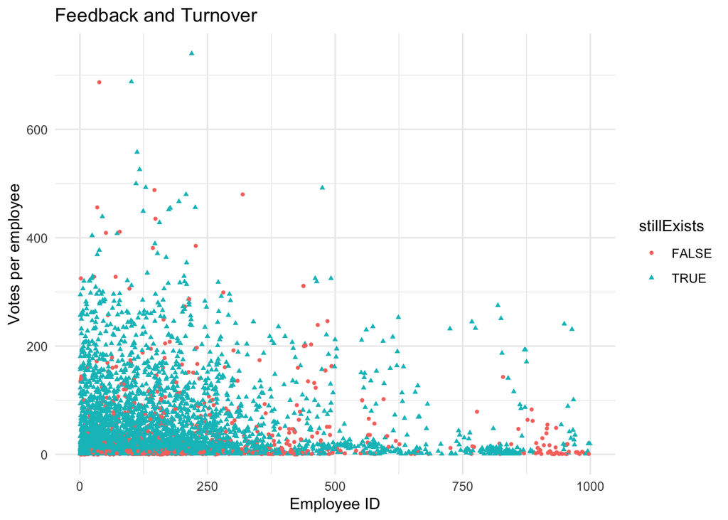

#Conclusion6: The interesting graph created shows us that the employees labeled with a blue triangle (employees who are still on the company), are also those that voted more. This shows a possible relationship between giving feedback and not leaving the company.

The next question we attempt to answer is the main question of our work. Is there a relationship between the vote and the reactions created?

To answer that question we will test some hypothesis. The first one is that the extreme votes (1 or 4) generates more reactions than average votes (2 and 3) since people will have a tendency to disagree with them. So to test that hypothesis we will create a new object (votes_reactions) that will serve as the basis of the next objects we will create to generate 3 graphs.

```r
votes_reactions <- votes %>%
  left_join(commentclean) %>%
  select(vote, commentId, likes, dislikes) %>%
  na.omit()
votes_reactions$reactions <- votes_reactions$likes + votes_reactions$dislikes
```

## Reactions (Likes + Dislikes) per vote

```r
votes_reactions_total <- votes_reactions %>%
  group_by(vote) %>%
  summarise(sum(reactions))
names(votes_reactions_total)[2] <- 'reactions_total'
```

# Graph: Total Reactions per type of vote

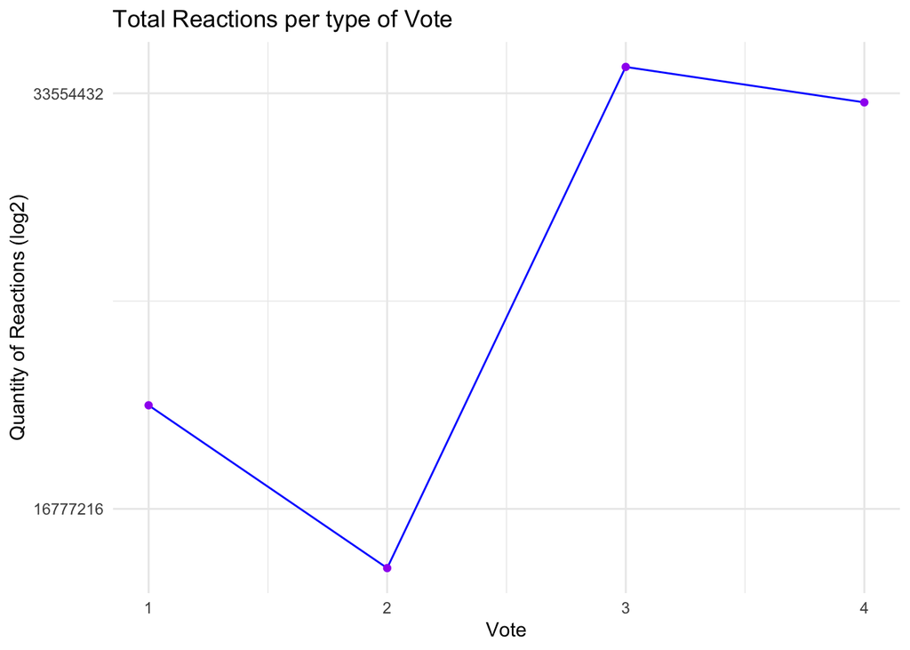

## Conclusion7

Our hypothesis does not seem completely incorrect. Although the vote that has produced more reactions was 3, 4 and 1 were respectively second and third. The vote that generates much less reactions than the others is 2. However, does that mean that people agree more with the vote 3 or disagree ?

Let’s analyse first the agreement (likes) and then the disagreement (dislikes)

## Likes per vote: Data Wrangling

```r
votes_reactions_likes <- votes_reactions %>%
  group_by(vote) %>%
  summarise(sum(likes))
names(votes_reactions_likes)[2] <- 'likes_total'
```

## Graph: Total Likes per Vote

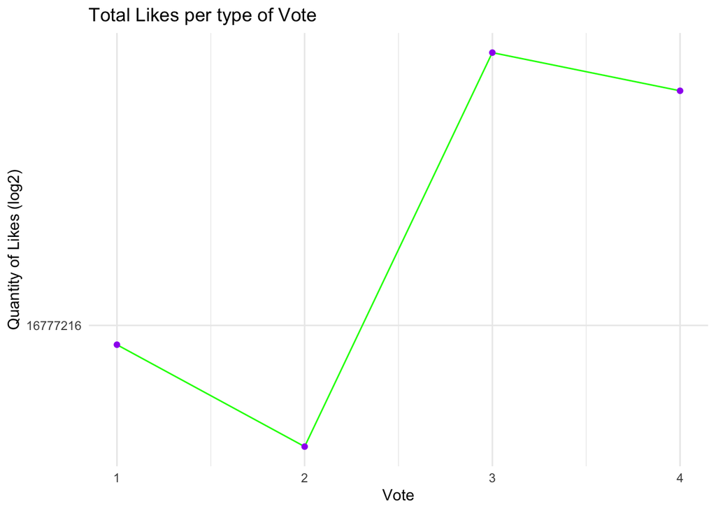

However, what about dislikes per vote?

## Dislikes per vote: Data Wrangling

```r
votes_reactions_dislikes <- votes_reactions %>%
  group_by(vote) %>%
  summarise(sum(dislikes))
names(votes_reactions_dislikes)[2] <- 'dislikes_total'
```

## Graph dislikes per type of vote:

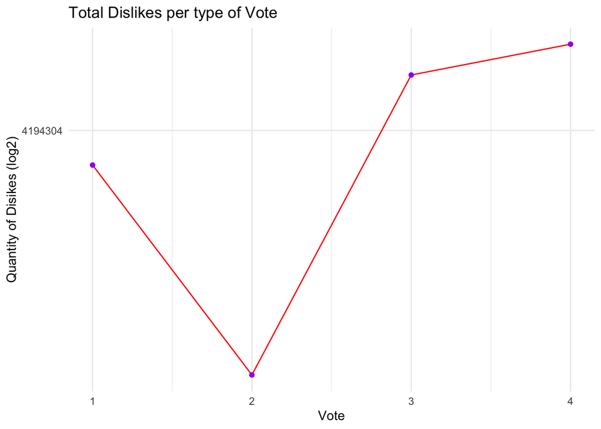